# Scatterplots and Correlation

## Introduction

- In this module, we begin discussing regression analysis.
- Regression is a very, very wide area.
  - We are barely scratching the surface.
- SDS II will deepen your understanding on statistical modeling techniques.

## `R` Set Up

```r
library(tidyverse)
library(ssstats)
training <- read_csv("https://raw.githubusercontent.com/samanthaseals/SDSI/refs/heads/main/files/data/lectures/7-1-training.csv")
wellness <- read_csv("https://raw.githubusercontent.com/samanthaseals/SDSI/refs/heads/main/files/data/lectures/7-2-wellness.csv")
reports <- read_csv("https://raw.githubusercontent.com/samanthaseals/SDSI/refs/heads/main/files/data/lectures/7-3-reports.csv")
break_room <- read_csv("https://raw.githubusercontent.com/samanthaseals/SDSI/refs/heads/main/files/data/lectures/7-4-break_room.csv")
```

## Scatterplots

- A **scatterplot** is a graph that shows the relationship between two quantitative variables measured on the same individual.
- Every individual in the dataset is represented by a point on the scatterplot.
- Note! The explanatory variable is on the $x$-axis and the response variable is on the $y$-axis.
- Like we have seen before, plotting the data is a first step in identifying issues.

## Scatterplots

- **Positive relationship:** As $x$ increases, $y$ also increases.

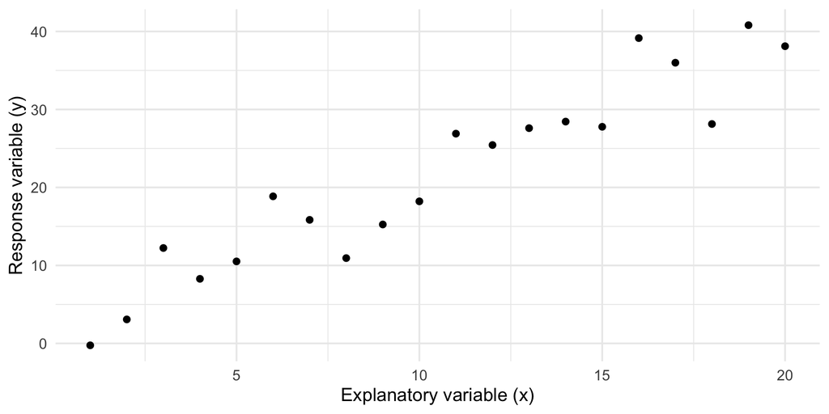

## Scatterplots

- **Negative relationship:** As $x$ increases, $y$ decreases.

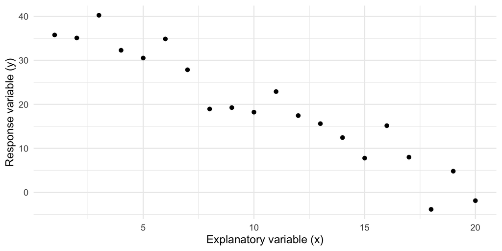

## Scatterplots

- **No relationship:** As $x$ increases, we cannot predict what happens to $y$.

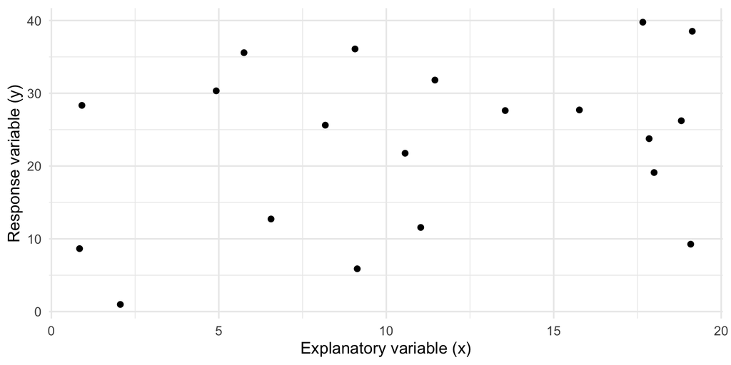

## Scatterplots

- Hmmmm…

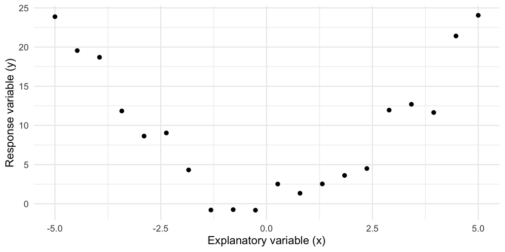

## Scatterplots

- Hmmmm…

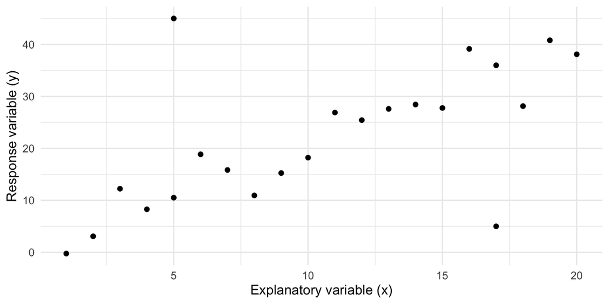

## Scatterplot (`R`)

- To construct a scatterplot in `R`, the base code uses `ggplot()` from the `ggplot2` package (called in with `tidyverse`).

```r
dataset_name |> ggplot(aes(x = x_variable, y = y_variable)) +
  geom_point() +
  theme_minimal() +
  labs(x = "Explanatory variable (x)",
       y = "Response variable (y)")
```

## Example 1

- Okonkwo stops by your desk: “Training division keeps encouraging recruits to spend more time on practice exercises. Before we build extra practice time into the schedule, I want to know if recruits who practice more tend to score higher?”
- We will examine the following question using the `training` dataset:
  - Is there a relationship between weekly practice hours ($x$) and exam score ($y$)?

| practice_hours | exam_score |
| --- | --- |
| 6.7 | 68.7 |
| 1.4 | 56.6 |
| 1.4 | 63.0 |

## Example 1

- Constructing the scatterplot,

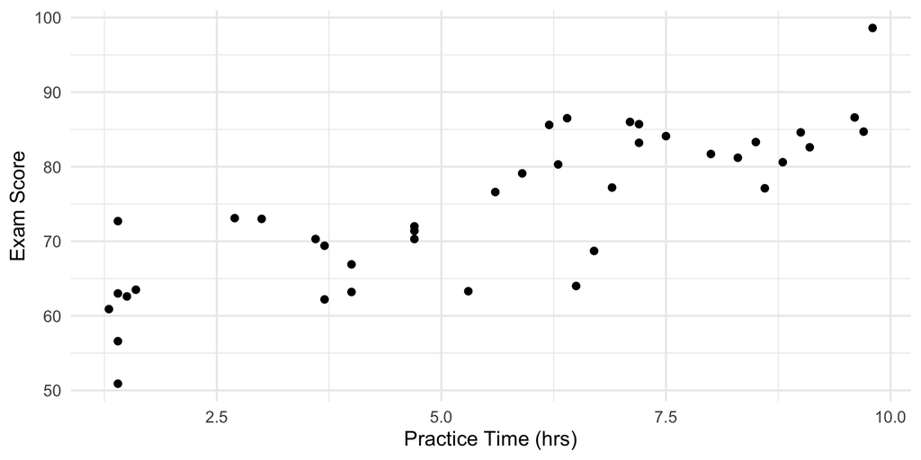

## Example 2

- Okonkwo raises an eyebrow: “Someone in records claims our taller officers write more accurate incident reports. … That can’t be true. Is there actually a relationship?”
- We will examine the following question using the `reports` dataset:
  - Is there a relationship between officer height ($x$) and report accuracy ($y$)?

| height_cm | report_accuracy |
| --- | --- |
| 198 | 75.5 |
| 129 | 82.7 |
| 89 | 78.0 |

## Example 2

- Constructing the scatterplot,

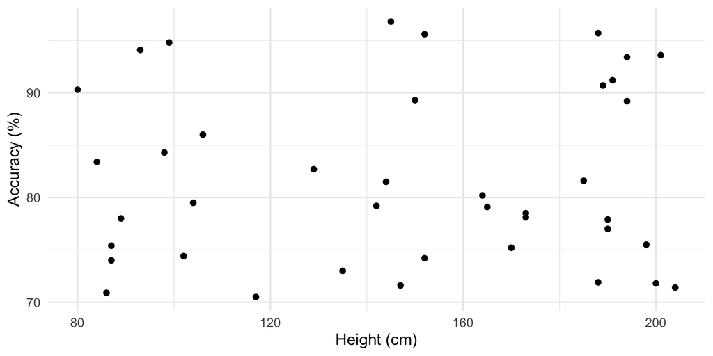

## Correlation

- **Correlation:** A measure of the strength and direction of the linear relationship between two quantitative variables.
  - $\rho$ represents the population correlation coefficient.
  - $r$ represents the sample correlation coefficient.
- Note!! Correlation is bounded to [-1, 1].
  - $r=-1$ represents perfect negative correlation.
  - $r=1$ represents perfect positive correlation.
  - $r=0$ represents no correlation.
- The closer |$r$| is to 1, the *stronger* the relationship between $x$ and $y$.

## Pearson’s Correlation Coefficient

- **Pearson’s correlation coefficient**:

$$r = \frac{\sum_{i=1}^n \left( \frac{x_i - \bar{x}}{s_x} \right)\left( \frac{y_i - \bar{y}}{s_y} \right)}{n-1},$$

- where
  - $x_i$ and $y_i$ make up the the $i$<sup>th</sup> observation
  - $\bar{x}$ and $\bar{y}$ are the sample means
  - $s_x$ and $s_y$ are the sample standard deviations
  - $n$ is the total sample size

## Pearson’s Correlation Coefficient

- We can also determine if a **linear** relationship exists.
- **Hypotheses:**
  - $H_0: \rho = 0$
  - $H_1: \rho \ne 0$
- **Test Statistic:**

$$t_0 = \frac{r \sqrt{n-2}}{\sqrt{1-r^2}} \sim t_{n-2}$$

## Pearson’s Correlation (`R`)

- We will use the `correlation()` function from `library(ssstats)`.
- Generic syntax:

```r
dataset_name |> correlation(x = 1st_continuous_variable,
                            y = 2nd_continuous_variable)
```

**1**

the first continuous variable in the correlation.

**2**

the second continuous variable in the correlation.

## Example 1

- Finding the correlation for the `training` dataset,
  - Is there a relationship between weekly practice hours ($x$) and exam score ($y$)?

```r
training |> correlation(x = practice_hours, y = exam_score)
```

| var1 | var2 | correlation | test_statistic | p_value |
| --- | --- | --- | --- | --- |
| practice_hours | exam_score | 0.82 | 8.837 | < 0.001 |

- Note that the choice (order) of $x$ and $y$ are arbitrary.

```r
training |> correlation(y = practice_hours, x = exam_score)
```

| var1 | var2 | correlation | test_statistic | p_value |
| --- | --- | --- | --- | --- |
| exam_score | practice_hours | 0.82 | 8.837 | < 0.001 |

## Example 1

- **Hypotheses:**
  - $H_0: \rho = 0$
  - $H_1: \rho \ne 0$
- **Test Statistic and $p$-Value:**
  - $t_0 = 8.837$
  - $p < 0.001$
- **Rejection Region:**
  - Reject $H_0$ if $p < \alpha$; $\alpha = 0.05$
- **Conclusion and Interpretation:**
  - Reject $H_0$. There is sufficient evidence to suggest that there is a linear relationship between the practice time and exam score.

## Example 2

- Finding the correlation for the `reports` dataset,
  - Is there a relationship between officer height ($x$) and report accuracy ($y$)?

```r
reports |> correlation(height_cm, report_accuracy)
```

| var1 | var2 | correlation | test_statistic | p_value |
| --- | --- | --- | --- | --- |
| height_cm | report_accuracy | 0.046 | 0.285 | 0.777 |

## Example 2

- **Hypotheses:**
  - $H_0: \rho = 0$
  - $H_1: \rho \ne 0$
- **Test Statistic and $p$-Value:**
  - $t_0 = 0.285$
  - $p = 0.777$
- **Rejection Region:**
  - Reject $H_0$ if $p < \alpha$; $\alpha = 0.05$
- **Conclusion and Interpretation:**
  - Fail to reject $H_0$. There is not sufficient evidence to suggest that there is a linear relationship between height and report accuracy.

## Assumptions on Pearson’s Correlation (`R`)

```r
dataset_name |> correlation_qq(x = 1st_continuous_variable,
                               y = 2nd_continuous_variable)
```

**1**

the first continuous variable in the correlation.

**2**

the second continuous variable in the correlation.

## Example 1

- Checking the assumption,

```r
training |> correlation_qq(practice_hours, exam_score)
```

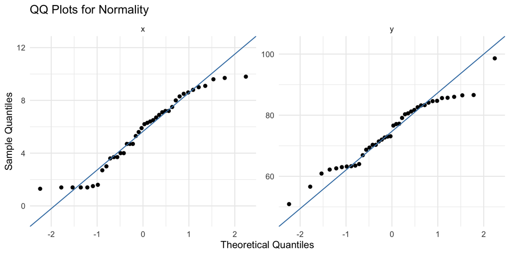

## Example 2

- Checking the assumption,

```r
reports |> correlation_qq(height_cm, report_accuracy)
```

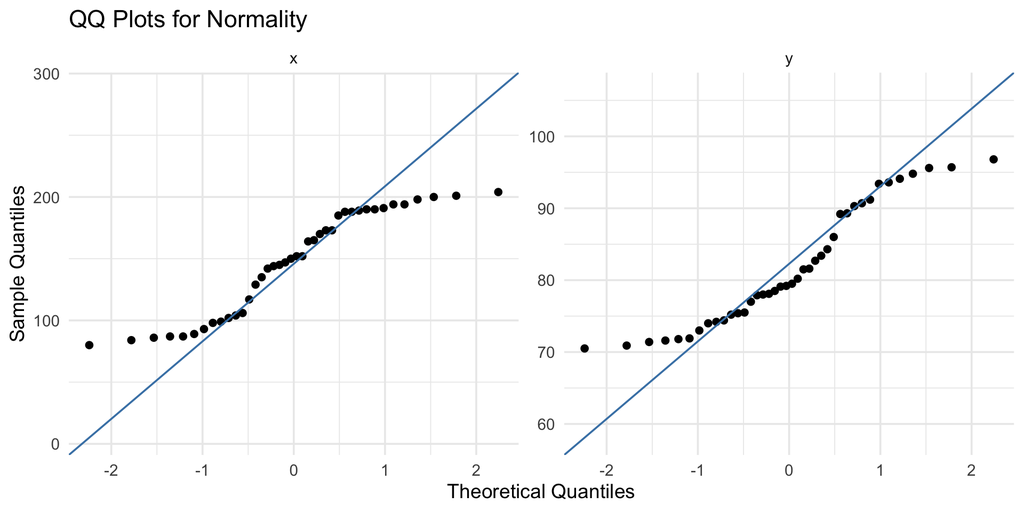

## Spearman’s Correlation Coefficient

- Spearman’s correlation coefficient is a nonparametric alternative to Pearson’s correlation.
  - Spearman’s correlation only assumes that the data is ordinal.
  - It *does not* work for nominal data.
- To compute Spearman’s, the following algorithm is used:
  1. Rank the $x$ and, separately, the $y$ values.
     - ($x$, $y$) $\to$ ($R_x$, $R_y$)
  2. Find Pearson’s correlation for the ranked data.
- Spearman’s correlation is interpreted the same as Pearson’s correlation.

- We can also determine if a **monotonic** relationship exists.
- **Hypotheses:**
  - $H_0: \rho_S = 0$
  - $H_1: \rho_S \ne 0$
- **Test Statistic:**

$$S = \frac{n(n^2 - 1)}{6}(1 - r_s)$$

## Spearman’s Correlation (`R`)

- We will again use the `correlation()` function from `library(ssstats)`.
- Generic syntax:

```r
dataset_name |> correlation(x = 1st_continuous_variable,
                            y = 2nd_continuous_variable,
                            method = "spearman")
```

**1**

the first continuous variable in the correlation.

**2**

the second continuous variable in the correlation.

**3**

request Spearman’s correlation instead of Pearson’s.

## Example 2

- Finding the Spearman’s correlation for the `reports` dataset,
  - Is there a relationship between officer height ($x$) and report accuracy ($y$)?

```r
reports |> correlation(height_cm, report_accuracy,
                       method = "spearman")
```

| var1 | var2 | correlation | test_statistic | p_value |
| --- | --- | --- | --- | --- |
| height_cm | report_accuracy | 0.025 | 10396.93 | 0.880 |

## Wrap Up

- guessthecorrelation.com!
- In the next lectures, we will learn how to quantify the relationship between $x$ and $y$ using regression analysis.